# Los Angeles airport passenger prediction with Box Jenkins

## Recheck for Heteroscedasticity

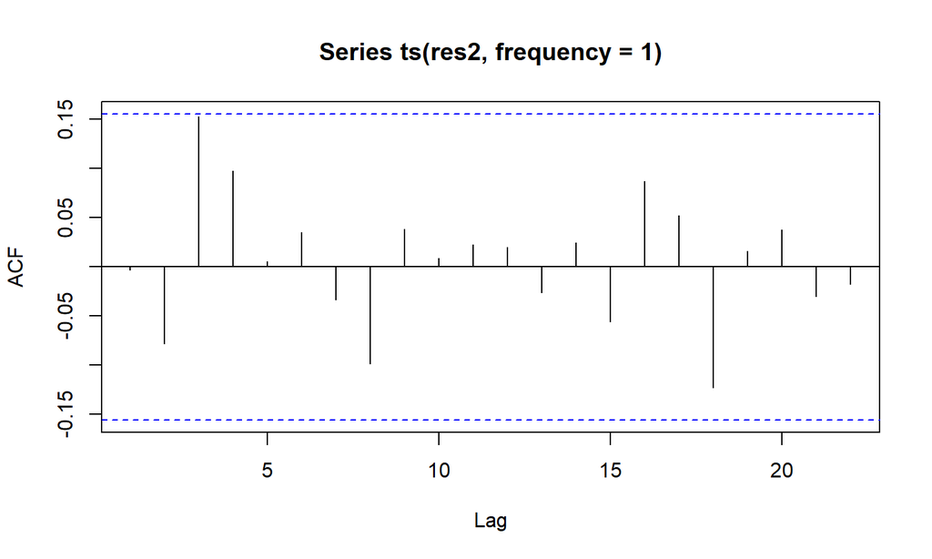

```r
acf(ts(res2, frequency=1))
```

No, it seems that there is no more significant coefficients which would say that we have homoscedaticity (don’t need to use garch model)

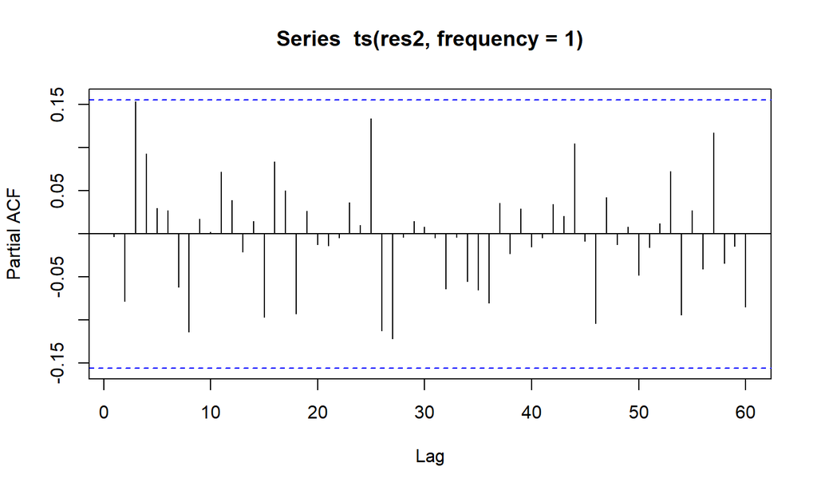

```r
pacf(ts(res2, frequency=1),lag.max = 60)
```

### McLeod.Li.test

```r
Htest <- McLeod.Li.test(mod2, plot=FALSE)
Htest
```

```
## $p.values
##  [1] 0.5394025 0.2348160 0.3195137 0.4196310 0.2527477 0.3339364 0.1219653
##  [8] 0.1173913 0.1656550 0.1694314 0.1164518 0.1479106 0.1682702 0.2058382
## [15] 0.1457133 0.1678925 0.2017905 0.1765099 0.1946852 0.2091475 0.2556971
```

H0 is always accepted : homoscedaticity here !

## 4. Prediction

Now that we have a model built, we want to use it to make forecasts. But first we should validate the model with an in-sample analysis.

### In-sample analysis

First, let’s assess the quality of the fit

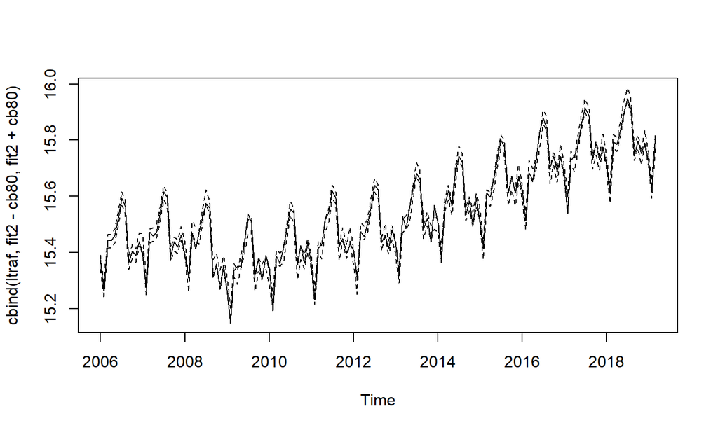

```r
cb80 <- mod2$sigma2^.5*qnorm(0.9)
plot(cbind(ltraf,fit2-cb80,fit2+cb80),plot.type='single',lty=c(1,2,2))
```

and the Proportion of points in the confidence bound

```r
indi <- (ltraf-(fit2-cb80))>0&(fit2+cb80-ltraf)>0
prop <- 100*sum(indi)/length(indi)
prop
```

```
## [1] 81.13208
```

Here, the proportion is larger than 80%, then the fit is considered good.